# An Introduction to R

Jimmy Azar

## Introduction

R is a free software environment for statistical computing and graphics. It contains most standard methods of statistics (as well as lot of less commonly used methods) and can be used for programming and to construct your own functions. It’s available for download from:

http://www.r-project.org

The primary purpose of this exercise is to introduce R. It is divided into three parts: a general introduction (simple calculations, vectors and graphics), descriptive statistics, and simulation.

## Getting started with R

The instructions given here will assume that you are using the Windows version of R. However, R is also available for MacOS X and Linux, and the only real difference between the three versions are the graphical interfaces used. Thus, all code presented here should work equally well on all three systems.

Start R through RStudio. You’ll find the R prompt, where you can write commands.

### Simple calculations, vectors and graphics

To begin with, we’ll use R as a calculator. Try the following commands:

2+7

2/(3+5)

sqrt(9)+5^2

sin(pi/2)-log(exp(1))

Help about a specific command can be found by writing a question mark before the command, for instance:

```r
?log
```

As an alternative, `help` can be used; in this case, `help(log)`. The help files are a great resource and you will soon find yourself using them frequently.

Comments can be written using the # symbol as follows:

```r
2+3 # The answer should be 5
```

```
## [1] 5
```

### Vectors and matrices

Vectors and matrices are of great importance in many numerical problems. To create a vector named `hello` and assign the values 7, −2, 5, 8 to it, we write as follows:

```r
hello <- c(7,-2,5,8)
```

The symbol <- should be read as “assigns”. The command `c` can be interpreted (by you, the user) as *combine* ; it combines the given numbers into a vector.

You can now look at the vector `hello` by typing

```r
hello
```

```
## [1]  7 -2  5  8
```

The second element of the vector can be referred to by the command

```r
hello[2]
```

```
## [1] -2
```

and elements between 2 and 4 (i.e. elements 2, 3 and 4) by

```r
hello[2:4]
```

```
## [1] -2  5  8
```

Vectors can be manipulated, for instance by adding a constant to all elements, as follows.

```r
myconst <- 100; hello + myconst
```

```
## [1] 107  98 105 108
```

Using the semicolon allows us to write multiple commands on a single line.

A vector `x` consisting of the integers between 1 and 10; 1, 2, …, 10; can be created by writing

```r
x <- c(1:10)
```

Vectors with sequences of numbers with particular increments can be created with the `seq` command:

```r
h <- seq(0,10,2) # integers between 0 and 10, with increment 2
```

The commands `rbind` and `cbind` can be used to merge row or column vectors to matrices. Try the following:

```r
x <- c(1,2,3); y <- c(4,5,6); A = cbind(x,y); B = rbind(x,y); C = t(B)
```

(The last command gives the matrix transpose of B). Now type A, B and C to see what the different matrices look like.

Matrix multiplication is performed using `%*%` (e.g. `B %*% x`) and matrices can be inverted using the command `solve`.

### Simple graphics

Graphs of functions can be drawn by constructing suitable vectors and using the plot command.

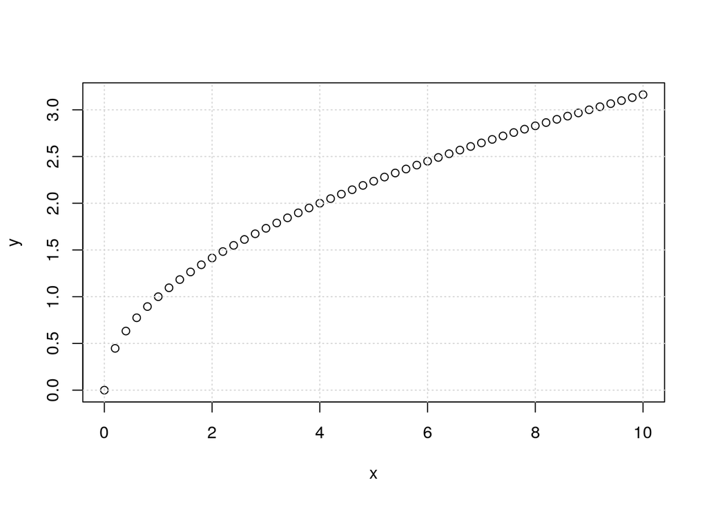

```r
x <- seq(0,10,0.2)
y <- sqrt(x)
plot(x,y); grid()
```

(As one might guess, the last command adds a grid to the plot.)

**Exercise 1**. Plot the function $y = x^2$ in the interval $−2 \leq x \leq 2$. (Think about what you want to accomplish with the plot: function values in a few discrete points or a nice smooth curve? Think about how different arguments in the `seq` and `plot` functions can be used. Use the help files to find suitable arguments!)

As an alternative, a simple way of plotting a function is to use the command `curve`:

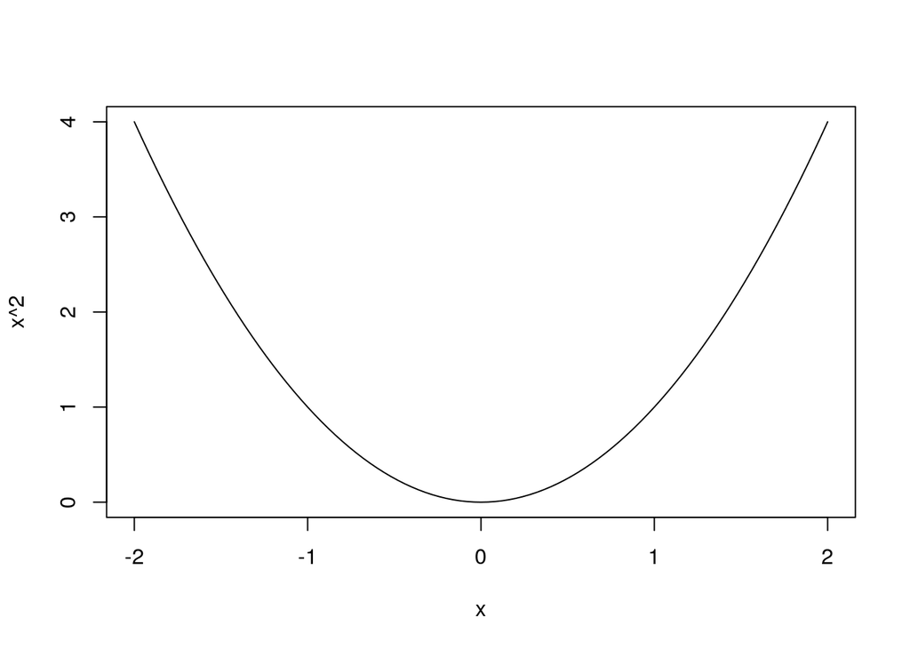

```r
curve(x^2,-2,2)
```

## Handling data

### Creating data frames

The command `data.frame` can be used to organize data of different kinds and to extract subsets of the data. Assume that we have data about three persons and that we store it as follows:

```r
length <- c(180,175,190); weight <- c(75,82,88);
name <- c("Adam","Bob","Carl")
friends <- data.frame(name,length,weight)
```

`friends` is now a data frame containing the data for the three persons. Data can easily be extracted:

```r
my.names <- friends$name
length1 <- friends$length[1]
```

### Reading data from files

It is common that data is stored in a text file and that we wish to import the data to R. We will study two cases; one with purely numerical data and one with numerical data with headers. In the file `coins.dat` data about the amount of silver in 27 silver coins from different epochs is stored. When we use the command

```r
mynt1 <- read.table("coins.dat")
```

R creates a structure with two columns with headers V1 (amount of silver) and V2 (epoch).

**Note**: If you receive an error message, it’s probably because the file is not in your *working directory*. In the menu, choose `Session` and then `Set Working Directory` and change the working directory to the one where you have stored the file. Unless the complete path to the file is explicitly written, R assumes that all files that we try to open are in the working directory.

To see the properties of the tenth observation we write

```r
mynt1[10,] # [10,] means "everything on row 10"
```

```
##     V1 V2
## 10 6.9  2
```

If we only want to see the amount of silver in the tenth coin we write

```r
mynt1$V1[10] # vector V1 (the first vector), row 10
```

```
## [1] 6.9
```

or

```r
mynt1[10,1] # row 10, column 1
```

```
## [1] 6.9
```

Clearly, it’s important to know which data is stored in which column. To make this clear one can give the columns headers when importing the data:

```r
mynt2 <- read.table("coins.dat",col.names=c("Silver","Epoch"))
```

so that the strings `Silver` and `Epoch` will be used instead of `V1` and `V2`.

Let us now study the same data set, but with the data stored in a slightly different way. The file `coins.txt` has the same data stored, but with headers stored on the first row of the file. To import the data with headers we write

```r
mynt2 <- read.table("coins.txt", header=TRUE)
```

Try to access information about particular observations as before!

There are functions for importing data from, for instance, databases or Excel spreadsheets as well. Usually, however, one can copy or save the data from the database or the spreadsheet to a text file and then import it, so that the `read.table` command can be used.

## Analysis of a data set: Cars

A multitude of data sets are shipped with R. We will study a data set from the early 70’s, with data about different cars.

Load the data set by writing

```r
data(mtcars)
```

You can read more about the data by looking at the help file:

```r
?mtcars
```

**Exercise 2**. Answer the following questions using the help file:

1. How many cars are included in the data set?
2. Which years are the models from?
3. What does the `mpg` value desribe?

To see the entire data set, simply write

```r
mtcars
```

```
##                      mpg cyl  disp  hp drat    wt  qsec vs am gear carb
## Mazda RX4           21.0   6 160.0 110 3.90 2.620 16.46  0  1    4    4
## Mazda RX4 Wag       21.0   6 160.0 110 3.90 2.875 17.02  0  1    4    4
## Datsun 710          22.8   4 108.0  93 3.85 2.320 18.61  1  1    4    1
## Hornet 4 Drive      21.4   6 258.0 110 3.08 3.215 19.44  1  0    3    1
## Hornet Sportabout   18.7   8 360.0 175 3.15 3.440 17.02  0  0    3    2
## Valiant             18.1   6 225.0 105 2.76 3.460 20.22  1  0    3    1
## Duster 360          14.3   8 360.0 245 3.21 3.570 15.84  0  0    3    4
## Merc 240D           24.4   4 146.7  62 3.69 3.190 20.00  1  0    4    2
## Merc 230            22.8   4 140.8  95 3.92 3.150 22.90  1  0    4    2
## Merc 280            19.2   6 167.6 123 3.92 3.440 18.30  1  0    4    4
## Merc 280C           17.8   6 167.6 123 3.92 3.440 18.90  1  0    4    4
## Merc 450SE          16.4   8 275.8 180 3.07 4.070 17.40  0  0    3    3
## Merc 450SL          17.3   8 275.8 180 3.07 3.730 17.60  0  0    3    3
## Merc 450SLC         15.2   8 275.8 180 3.07 3.780 18.00  0  0    3    3
## Cadillac Fleetwood  10.4   8 472.0 205 2.93 5.250 17.98  0  0    3    4
## Lincoln Continental 10.4   8 460.0 215 3.00 5.424 17.82  0  0    3    4
## Chrysler Imperial   14.7   8 440.0 230 3.23 5.345 17.42  0  0    3    4
## Fiat 128            32.4   4  78.7  66 4.08 2.200 19.47  1  1    4    1
## Honda Civic         30.4   4  75.7  52 4.93 1.615 18.52  1  1    4    2
## Toyota Corolla      33.9   4  71.1  65 4.22 1.835 19.90  1  1    4    1
## Toyota Corona       21.5   4 120.1  97 3.70 2.465 20.01  1  0    3    1
## Dodge Challenger    15.5   8 318.0 150 2.76 3.520 16.87  0  0    3    2
## AMC Javelin         15.2   8 304.0 150 3.15 3.435 17.30  0  0    3    2
## Camaro Z28          13.3   8 350.0 245 3.73 3.840 15.41  0  0    3    4
## Pontiac Firebird    19.2   8 400.0 175 3.08 3.845 17.05  0  0    3    2
## Fiat X1-9           27.3   4  79.0  66 4.08 1.935 18.90  1  1    4    1
## Porsche 914-2       26.0   4 120.3  91 4.43 2.140 16.70  0  1    5    2
## Lotus Europa        30.4   4  95.1 113 3.77 1.513 16.90  1  1    5    2
## Ford Pantera L      15.8   8 351.0 264 4.22 3.170 14.50  0  1    5    4
## Ferrari Dino        19.7   6 145.0 175 3.62 2.770 15.50  0  1    5    6
## Maserati Bora       15.0   8 301.0 335 3.54 3.570 14.60  0  1    5    8
## Volvo 142E          21.4   4 121.0 109 4.11 2.780 18.60  1  1    4    2
```

**Exercise 3**. To get familiar with the data set, answer the following non-statistical questions.

1. Are there any cars that weigh more than 5000 (lb/1000)?
2. How many cylinders does the motor of the Volvo 142E have?
3. Are there any cars with 5 forward gears? Do they have automatic or manual transmisson?
4. Experiment with the command `subset()`. What do the commands `subset(mtcars,gear==5)` and `subset(mtcars,(wt>5 & disp<470))` do?

### Descriptive statistics

Data can be summarized using simple measures such as mean, median, standard deviation, maximum and minimum and so on. A summary of a few such measures for the `mtcars` data set is obtained by writing

```r
summary(mtcars)
```

```
##       mpg             cyl             disp             hp
##  Min.   :10.40   Min.   :4.000   Min.   : 71.1   Min.   : 52.0
##  1st Qu.:15.43   1st Qu.:4.000   1st Qu.:120.8   1st Qu.: 96.5
##  Median :19.20   Median :6.000   Median :196.3   Median :123.0
##  Mean   :20.09   Mean   :6.188   Mean   :230.7   Mean   :146.7
##  3rd Qu.:22.80   3rd Qu.:8.000   3rd Qu.:326.0   3rd Qu.:180.0
##  Max.   :33.90   Max.   :8.000   Max.   :472.0   Max.   :335.0
##       drat             wt             qsec             vs
##  Min.   :2.760   Min.   :1.513   Min.   :14.50   Min.   :0.0000
##  1st Qu.:3.080   1st Qu.:2.581   1st Qu.:16.89   1st Qu.:0.0000
##  Median :3.695   Median :3.325   Median :17.71   Median :0.0000
##  Mean   :3.597   Mean   :3.217   Mean   :17.85   Mean   :0.4375
##  3rd Qu.:3.920   3rd Qu.:3.610   3rd Qu.:18.90   3rd Qu.:1.0000
##  Max.   :4.930   Max.   :5.424   Max.   :22.90   Max.   :1.0000
##        am              gear            carb
##  Min.   :0.0000   Min.   :3.000   Min.   :1.000
##  1st Qu.:0.0000   1st Qu.:3.000   1st Qu.:2.000
##  Median :0.0000   Median :4.000   Median :2.000
##  Mean   :0.4062   Mean   :3.688   Mean   :2.812
##  3rd Qu.:1.0000   3rd Qu.:4.000   3rd Qu.:4.000
##  Max.   :1.0000   Max.   :5.000   Max.   :8.000
```

Measures can also be studied one at a time:

```r
mean(mtcars$hp); median(mtcars$hp); quantile(mtcars$wt); max(mtcars$mpg)
```

```
## [1] 146.6875
```

```
## [1] 123
```

```
##      0%     25%     50%     75%    100%
## 1.51300 2.58125 3.32500 3.61000 5.42400
```

```
## [1] 33.9
```

```r
sd(mtcars$mpg) # standard deviation
```

```
## [1] 6.026948
```

```r
var(mtcars$mpg) # variance
```

```
## [1] 36.3241
```

```r
sd(mtcars$mpg)^2 # sd*sd=var?
```

```
## [1] 36.3241
```

The command `attach` is very useful when dealing with data frames. By writing `attach(mtcars)` the references to the variables in mtcars can be shortened; instead of the long references above we can write:

```r
attach(mtcars)
mean(hp); median(hp); quantile(wt); max(mpg)
```

```
## [1] 146.6875
```

```
## [1] 123
```

```
##      0%     25%     50%     75%    100%
## 1.51300 2.58125 3.32500 3.61000 5.42400
```

```
## [1] 33.9
```

**Exercise 4**.

1. What is the lowest value of `mpg`?
2. Which is the heaviest car in the data set?
3. What does the median of `am` tell us?

### Visualising data

#### Histograms

A histogram can be used to study the distribution of continuous data. Unless they are explicitly stated, R chooses the numbers of classes and class width when the command `hist` is used. The sequence of commands below plots two histograms in one window, the first being the histogram for `mpg` and the second for `wt`.

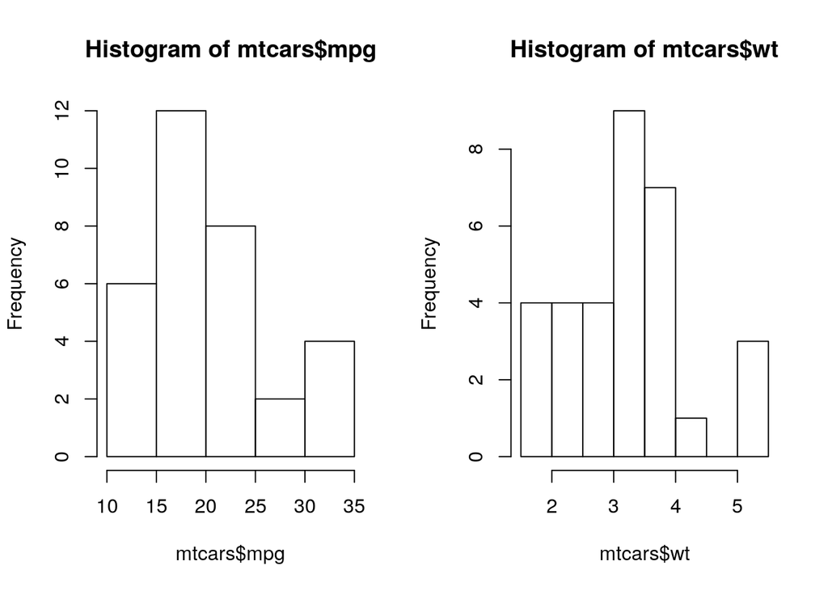

```r
par(mfrow=c(1,2)); hist(mtcars$mpg); hist(mtcars$wt)
```

`par(mfrow=c(a,b))` gives *a* rows with *b* plots on each row. Using the argument `freq` when calling `hist` we can plot a histogram with relative frequencies instead of frequencies. Such histograms can be viewed as estimates of the density function of the data. Read in the help file about what `hist(mtcars$mpg,freq=FALSE)` means and then see for yourself by typing the command.

#### Boxplots

Boxplots are also a useful tool for studying data. It shows the median, quartiles and possible outliers. The R command is `boxplot`, which we use on the same variables as the histogram:

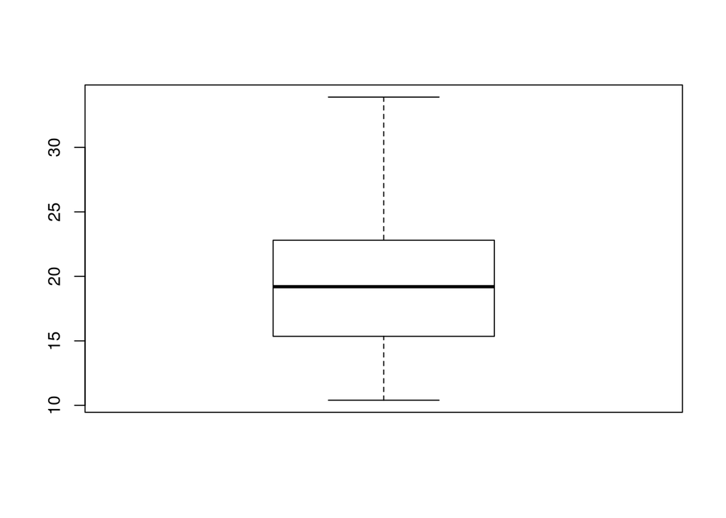

```r
boxplot(mtcars$mpg); x11(); boxplot(mtcars$wt)
```

The `x11()` command opens a new window in which the next figure will be plotted. Use the command `median()` to see if the boxplot really gives the right median for the variables.

#### Scatter plots

Scatterplots are useful for studying dependencies between variables. Try writing

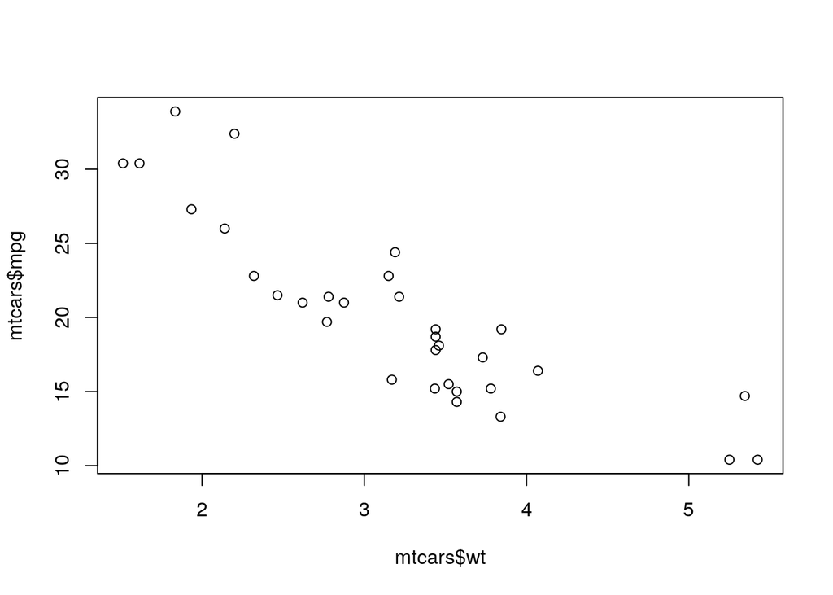

```r
plot(mtcars$wt,mtcars$mpg)
```

Does the slope of the cluster seem reasonable? The correlation (which measures linear dependence) can be calculated using the command `cor()` (use the help file to see how). What is the correlation in this case? Does it agree with the slope?

**Exercise 5**.

1. Plot histograms for the variables `hp` and `qsec`.
2. Plot boxplots for `hp` and `qsec`.
3. Plot scatter plots for `hp` and `qsec`. Comments?

## Simulation of random numbers

Most modern statistical software include routines for simulating random numbers from common distributions. We will study random number generation from two continuous distributions; the normal distribution with mean $\mu$ and variance $\sigma^2$, i.e. with density function:

$$f_X(x) = \dfrac{1}{\sigma \sqrt{2 \pi}} e^{-(x-\mu)^2/ (2\sigma^2)}, \hspace{1em} -\infty<x<\infty$$
and the exponential distribution with rate $\lambda$ and density:

$$f_X(x) = \lambda e^{-\lambda x}, \hspace{1em} 0 < x < \infty$$
Read more about the built-in functions for these distributions by typing `help(Normal)` and `help(Exponential)`, respectively. For instance, simulation of random numbers is done with the commands `rnorm()` and `rexp()`. Which parametrization of the exponential distribution is used in R? Try the following commands:

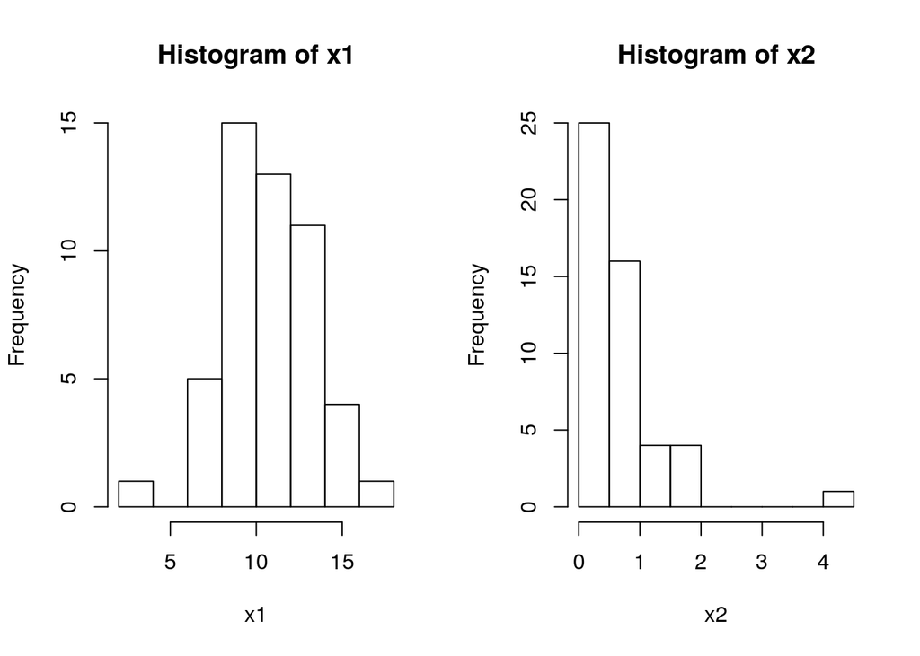

```r
n <- 50;
# Normal distribution
mu <- 10; sd <- 3; x1 <- rnorm(n,mu,sd)
# Exponential distribution
rate <- 2; x2 <- rexp(n,rate)
# Plot histograms of the simulated data
par(mfrow=c(1,2)); hist(x1); hist(x2)
```

It can be of interest to plot the true density function of the simulated random variables on top of the histograms. This is done by adding `add=TRUE` to a plot command. Note that the scales of the x-axis and y-axis must be choosen wisely. The choice can be done using the commands `xlim` and `ylim`, as is shown below. We make a new plot for the normal distribution as follows:

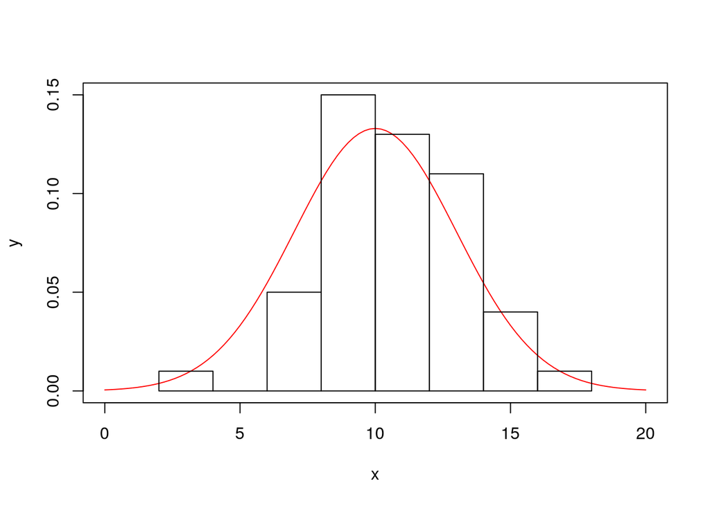

```r
mu <- 10; sd <- 3;
x <- seq(0,20,0.2); y <- dnorm(x,mu,sd);
plot(x,y,xlim=c(0,20),ylim=c(0,0.15),type="l",col="red")
hist(x1,freq=FALSE,add=TRUE)
```

What will happen if we increase the number *n* of simulated numbers? To investigate, we add two more histograms to the plot:

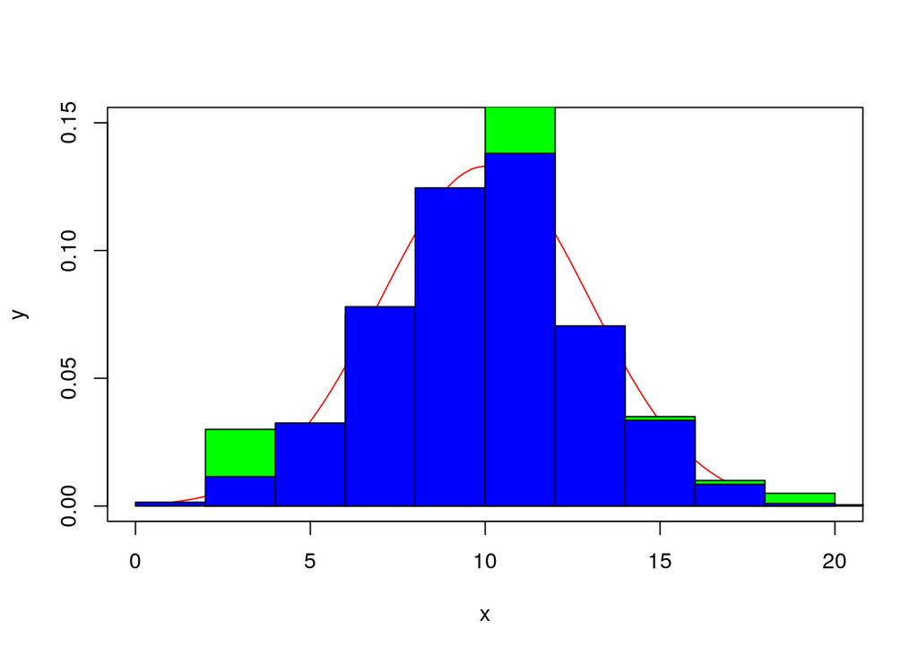

```r
mu <- 10; sd <- 3;
x <- seq(0,20,0.2); y <- dnorm(x,mu,sd);
plot(x,y,xlim=c(0,20),ylim=c(0,0.15),type="l",col="red")
x100 <- rnorm(100,mu,sd)
hist(x100,freq=FALSE,add=TRUE,col="green")
x1000 <- rnorm(1000,mu,sd)
hist(x1000,freq=FALSE,add=TRUE,col="blue")
```

We turn our attention to a less well-behaved distribution. A standard Cauchy variable has the density function

$$f_X(x) = \dfrac{1}{\pi (1+x^2)}, \hspace{1em} -\infty<x<\infty$$
It can be shown that mean and variance do not exist for the Cauchy distribution (while the median and mode are 0). We can investigate this numerically by plotting the observations of simulated Cauchy variables a few times. Repeat the following command to see how 100 generated Cauchy variables can vary from time to time:

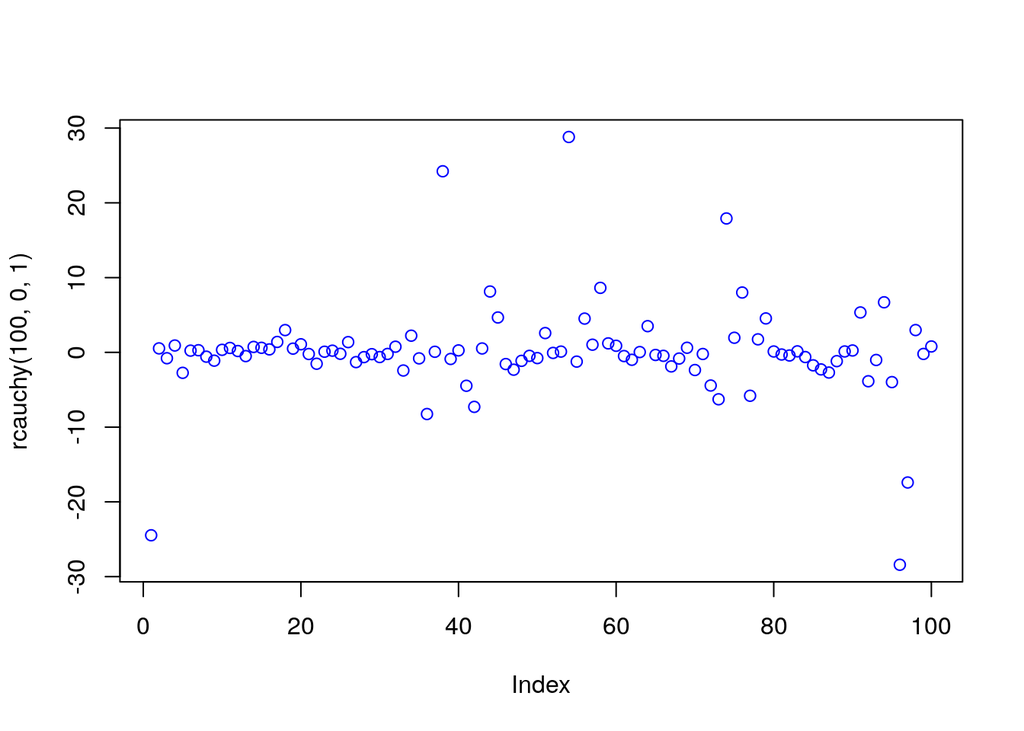

```r
plot(rcauchy(100,0,1),col=4)
```

## More advanced use of R

Eventually you might want to use R for somewhat more advanced programming. It is assumed that you already are familiar with programming; in particular that you have seen `if` conditions and loops before.

### A second look at vectors

We’ve seen that vectors can be created using `c()` or `seq()`. Another alternative is `rep()` which gives us vectors with certain patterns.

```r
x <- rep(1,10) # Gives the vector (1,1,1,1,1,1,1,1,1,1)
y <- rep(c(1,2,3),2) # Gives the vector (1,2,3,1,2,3)
z <- rep(c(1,2),c(2,3)) # Gives the vector (1,1,2,2,2)
```

Specific elements of vectors can be accessed using clever expressions for indexing. Here are some examples:

`x[n] # The n:th element of x`

`x[-n] # All elements but the n:th`

`x[a:b] # All elements between the a:th and the b:th`

`x[c(1,3,7)} # The first, the third and the seventh element`

`x[x>2] # All elements that are greater than 2`

### Programming

#### if statements and booleans

Boolean expressions can be written in R in much the same way as in many other programming languages. Here are some examples:

`a <- 1; b <- 2; c <- 3`

`a==a # Checks if a equals a`

`a==b # Checks if a equals b`

`a!=b # Checks if a does not equal b`

`a<b # Checks if a is less than b`

`a<=b # Checks if a is less than or equal to b`

`a<b && a<c # Checks if a is less than b _and_ if a is less than c`

`a<b || c<a # Checks if a is less than b or c is less than a`

Each expression returns either TRUE or FALSE. Boolean variables are variables that take either of these values. Boolean expressions are useful when using `if` statements. These can be used to make sure that certain parts of the code only run under special conditions. Here is an example of what an `if` statement can look like in R:

```r
iIsLarge <- FALSE; i <- 20
if (i >= 10) { iIsLarge <- TRUE } # Checks if i is large
iIsLarge # The boolean variable that tells us if i is large
```

```
## [1] TRUE
```

`if` can also be combined with `else` to control what happens if the boolean expression is false:

```r
i <- runif(1,0,20) # A random number between 0 and 20
if (i >= 10) { iIsLarge <- TRUE } else { iIsLarge <- FALSE }
iIsLarge
```

```
## [1] FALSE
```

#### Loops

Booleans can also be used in the `while` loop as follows:

```r
count=0; ourRandomNumber <- runif(1,0,40)
while (ourRandomNumber > 10)
{
  newRandomNumber <- runif(1,0,40)
  ourRandomNumber <- newRandomNumber
  count <- count+1 # Counts the number of iterations of the loop
}
count
```

```
## [1] 1
```

An alternative is the `for` loop:

```r
x <- rep(NA,10)
for (i in 1:10)
{
  x[i] <- i^2
}
x
```

```
##  [1]   1   4   9  16  25  36  49  64  81 100
```

Althought it is considered to be bad practice, the `break` command can be used to stop loops:

```r
x <- rep(NA,10)
for (i in 1:10)
{
  x[i] <- i^2
  if(i^2 > 10) { break }
}
x
```

```
##  [1]  1  4  9 16 NA NA NA NA NA NA
```

#### Functions

Creating new functions in R is quite easy. Consider the following example:

```r
powern <- function(x, n=2)
{
  z <- x^n
  return(z)
}
```

This creates a function `powern()` which takes two arguments, a vector (or scalar) `x` and a vector (or scalar) `n`. If the argument `n` is not given in the call then the default value `n=2` is used instead. The function returns `x^n`.

The function can now be called just as any other function:

`powern(2)`

`powern(3,1/2)`

`powern(6,-1)`

`x <- c(1,2,3); powern(x,x)`

However, if you want to use the function again, it must be defined once more each time that you start R (unless you choose to save the workspace image at the end of the previous session).

### Files and scripts

#### Saving text files

We saw that we could import data from text files into data frames using the `read.table()` command. In the same manner, we can save data as text files using `write.table()`. Here is an example that saves the *mtcars* data frame in the file `mtcars.txt`:

```r
data(mtcars)
write.table(mtcars, file="mtcars.txt")
```

The data can now be imported into R (by you or someone else) by the `read.table()` command.

#### Saving graphics

In the Windows version of R figures can be saved by right-clicking on them. An alternative is to save the figure by using the following code:

```r
x <- seq(0,1,by=0.1)
y <- x^2
pdf("fig1.pdf", width=8, height=8, title="My pdf")
plot(x, y, xlab="x-axis", ylab="y-axis", main="This is my plot")
dev.off()
```

This saves the plot in the file `fig1.pdf`. It is possible to save the figure in other file formats by exchanging

`pdf("fig1.pdf", ...`

in the above with any of the following:

`postscript("fig1.ps", ...`

`postscript("fig1.eps", ...`

`png(file="fig1.png", ...`

`jpeg(file="fig1.jpg", ...`

`bitmap(file="fig1.bmp", ...`

#### Executing scripts

If we’ve saved an R-script in the file `script.R` and want to execute it we can write

`source("script.R", echo=TRUE)`

If `echo=TRUE` is in the call the commands in the script are printed on the screen and if `echo=FALSE` then the script is executed without printing the commands.